# Final Assignment

### 4) The Stochastic Universe

1. Use Montecarlo methods to calculate the probability that a random team of 4 female superheros will overcome (total powers will be greater) a random team of 4 male superheros.

```r
f<-rnorm(100000,average_f-average_m,SD_f+SD_m)
a<-c(1:100000)
mont_car_val<-function(f,j){
  for(i in 1:100000){
  a[i]<-(sum(sample(f,4))>=0)

  }
  sum(a)/100000
}
mont_car_val(f,4)
```

```
## [1] 0.37797
```

2. Suppose DC Comics selects randomly and independently whether to choose a male or a female superhero: Write a Montecarlo simulation to test the hypothesis that the probability for choosing a female hero is 0.5. Use the observed number of heros.

```r
p_f<-sum(DC$Gender=="Female")/(length(DC[,1]))
DC_select<-rnorm(100000,p_f,sqrt(p_f*(1-p_f)))
sum(DC_select)/100000
```

```
## [1] 0.2871211
```

### 5) Your Own Take

Show graphically one interesting insight you have found in the provided datasets - this can be unrelated to the gender analysis we have carried.

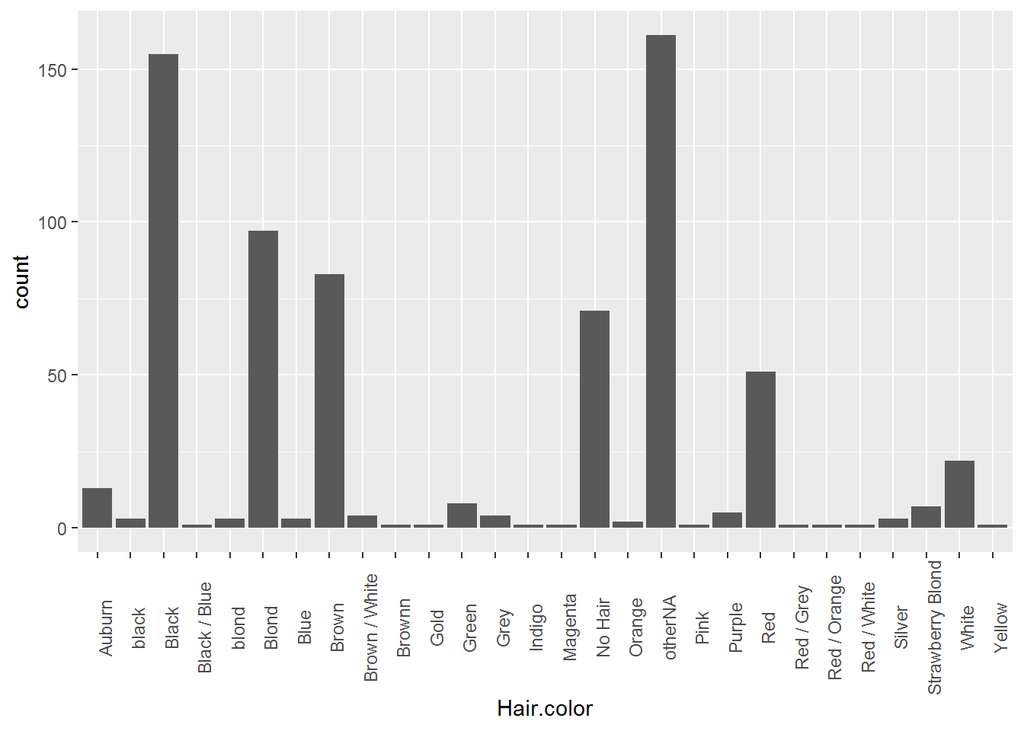

```r
df_heroes%>%ggplot(aes(Hair.color))+ geom_bar()  + theme(axis.text.x = element_text(angle = 90))
```

```r
#Most superheroues got regular color hair(blond, black, brown).
```